# Background

[figure not shown]

> Recorded historical documents give us a peek into the past. We are able to glimpse the world before our time; and see its culture, norms, and values to reflect on our own. Japan has very unique historical pathway. Historically, Japan and its culture was relatively isolated from the West, until the Meiji restoration in 1868 where Japanese leaders reformed its education system to modernize its culture. This caused drastic changes in the Japanese language, writing and printing systems. Due to the modernization of Japanese language in this era, cursive Kuzushiji (くずし字) script is no longer taught in the official school curriculum. Even though Kuzushiji had been used for over 1000 years, most Japanese natives today cannot read books written or published over 150 years ago.

> The result is that there are hundreds of thousands of Kuzushiji texts that have been digitised but have never been transcribed, and can only currently be read by a few experts. We've built Kuzushiji-MNIST and sister datasets by taking handwritten characters from these texts and preprocessing them in a format similar to the MNIST dataset, to create easy to use benchmark datasets that are more modern and difficult to classify than the original MNIST dataset.

> By releasing these datasets, we're also hoping to bring together the fields of Japanese literature and ML 😊

# The datasets

📚 [Read the paper](https://arxiv.org/abs/1812.01718) to learn more about Kuzushiji, the datasets and their motivations for making them!  
Download the dataset at [Kuzushi-MNIST](https://www.kaggle.com/datasets/anokas/kuzushiji).

Structure of the dataset:

```
Kuzushiji-MNIST
    ├── kmnist-test-imgs.npz
    ├── kmnist-test-labels.npz
    ├── kmnist-train-imgs.npz
    ├── kmnist-train-labels.npz
    ├── ...
```

kmnist-**[train/test]**-**[images/labels]**.npz: These files contain the Kuzushiji-MNIST as compressed numpy arrays.

```python
import os
import numpy as np
import pandas as pd
import matplotlib.pyplot as plt
import seaborn as sns

from sklearn.model_selection import train_test_split
from sklearn.metrics import confusion_matrix, accuracy_score

import tensorflow as tf
```

```python
DATA_DIR = '/kaggle/input/kuzushiji'
```

```python
X_path = os.path.join(DATA_DIR, 'kmnist-train-imgs.npz')
y_path = os.path.join(DATA_DIR, 'kmnist-train-labels.npz')

X_test_path = os.path.join(DATA_DIR, 'kmnist-test-imgs.npz')
y_test_path = os.path.join(DATA_DIR, 'kmnist-test-labels.npz')
```

```python
X = np.load(X_path)['arr_0']
y = np.load(y_path)['arr_0']
```

```python
print('X shape:', X.shape)
print('y shape:', y.shape)
```

```
X shape: (60000, 28, 28)
y shape: (60000,)
```

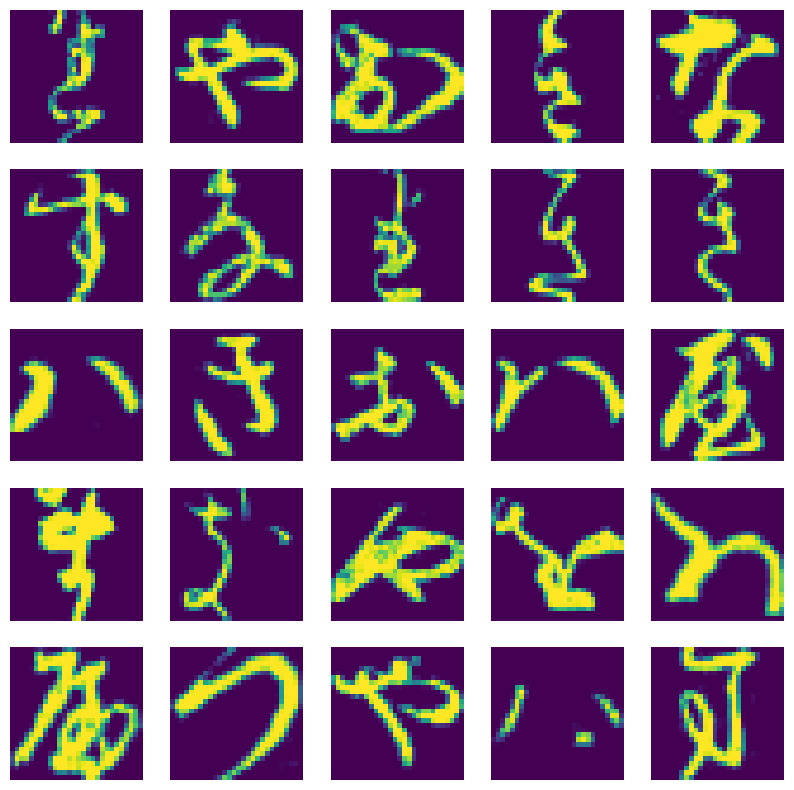

```python
# Plot some samples

plt.figure(figsize=(10, 10))
for i in range(25):
    plt.subplot(5, 5, i + 1)
    plt.imshow(X[i], cmap='viridis')
    plt.axis('off')
    plt.grid(False)
plt.show()
```

# Prepare dataset

```python
X = X.reshape(-1, 28, 28, 1)
X = X / 255.0
```

```python
X_train, X_valid, y_train, y_valid = train_test_split(X, y, test_size=0.2, stratify=y, random_state=42)
```

# Build the model

## 0. Configuration

```python
NUM_CLASSES = 10
IMG_SIZE = 28
BATCH_SIZE = 128
EPOCHS = 100

CALLBACKS = [tf.keras.callbacks.EarlyStopping(monitor='val_loss', patience=20)]
```

## 1. Baseline model

```python
baseline_model = tf.keras.Sequential([
    tf.keras.layers.Flatten(input_shape=(IMG_SIZE, IMG_SIZE)),
    tf.keras.layers.Dense(NUM_CLASSES, activation='softmax')
])

baseline_model.compile(optimizer=tf.keras.optimizers.Adam(learning_rate=0.001),
    loss=tf.keras.losses.SparseCategoricalCrossentropy(from_logits=False),
    metrics=['accuracy']
)

history = baseline_model.fit(
    X_train, y_train,
    validation_data=(X_valid, y_valid),
    epochs=EPOCHS, batch_size=BATCH_SIZE,
    callbacks=CALLBACKS
)
```

```python
loss_baseline, accuracy_baseline = baseline_model.evaluate(X_valid, y_valid, verbose=2)
```

```
375/375 - 1s - loss: 0.6185 - accuracy: 0.8186 - 763ms/epoch - 2ms/step
```

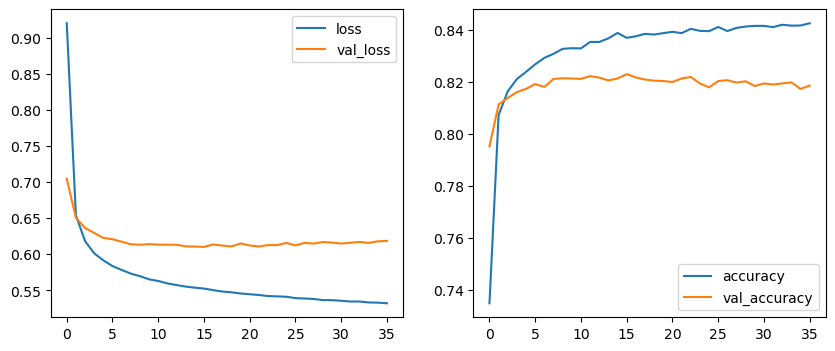

```python
plt.figure(figsize=(10, 4))
plt.subplot(1, 2, 1)
plt.plot(history.history['loss'], label='loss')
plt.plot(history.history['val_loss'], label='val_loss')
plt.legend()
plt.subplot(1, 2, 2)
plt.plot(history.history['accuracy'], label='accuracy')
plt.plot(history.history['val_accuracy'], label='val_accuracy')
plt.legend()
plt.show()
```

# 2. CNN model

```python
# Learning rate schedule func

def scheduler(epoch, lr):
    if epoch < 5:
        return lr
    else:
        return lr * tf.math.exp(-0.1)
```

```python
model = tf.keras.Sequential([
    tf.keras.layers.Conv2D(4, 3, activation='relu', input_shape=(IMG_SIZE, IMG_SIZE, 1)),
    tf.keras.layers.Conv2D(8, 3, activation='relu'),
    tf.keras.layers.MaxPooling2D(),
    tf.keras.layers.BatchNormalization(),

    tf.keras.layers.Conv2D(16, 3, activation='relu'),
    tf.keras.layers.Conv2D(16, 3, activation='relu'),
    tf.keras.layers.MaxPooling2D(),
    tf.keras.layers.BatchNormalization(),

    tf.keras.layers.Flatten(),
    tf.keras.layers.Dense(256, activation='relu'),
    tf.keras.layers.Dropout(0.5),
    tf.keras.layers.Dense(256, activation='relu'),
    tf.keras.layers.Dropout(0.5),
    tf.keras.layers.Dense(NUM_CLASSES, activation='softmax')
])

model.compile(optimizer=tf.keras.optimizers.Adam(learning_rate=0.001),
    loss=tf.keras.losses.SparseCategoricalCrossentropy(from_logits=False),
    metrics=['accuracy']
)

history = model.fit(
    X_train, y_train,
    validation_data=(X_valid, y_valid),
    epochs=EPOCHS, batch_size=BATCH_SIZE,
    callbacks=CALLBACKS + [tf.keras.callbacks.LearningRateScheduler(scheduler)]
)
```

```python
loss_cnn, accuracy_cnn = model.evaluate(X_valid, y_valid, verbose=2)
```

```
375/375 - 1s - loss: 0.0660 - accuracy: 0.9862 - 998ms/epoch - 3ms/step
```

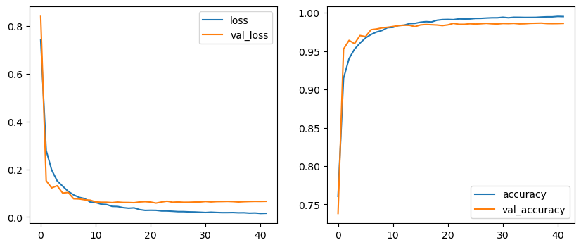

```python
plt.figure(figsize=(10, 4))
plt.subplot(1, 2, 1)
plt.plot(history.history['loss'], label='loss')
plt.plot(history.history['val_loss'], label='val_loss')
plt.legend()
plt.subplot(1, 2, 2)
plt.plot(history.history['accuracy'], label='accuracy')
plt.plot(history.history['val_accuracy'], label='val_accuracy')
plt.legend()
plt.show()
```

# Summary

```python
pd.DataFrame(
    {'Model': ['Baseline model', 'CNN model'],
     'Loss': [loss_baseline, loss_cnn],
     'Accuracy score': [accuracy_baseline, accuracy_cnn]}
)
```

|  | Model | Loss | Accuracy score |
| --- | --- | --- | --- |
| 0 | Baseline model | 0.618453 | 0.818583 |
| 1 | CNN model | 0.065979 | 0.986167 |

# Validate on testset

## Prepare testset

```python
X_test = np.load(X_test_path)['arr_0']
y_test = np.load(y_test_path)['arr_0']
```

```python
X_test = X_test.reshape(-1, 28, 28, 1)
X_test = X_test / 255.0
```

## Predict

```python
y_pred = model.predict(X_test, verbose=0)
y_pred = np.argmax(y_pred, axis=1)
```

```python
print('Accuracy score on testset:', accuracy_score(y_test, y_pred))
```

```
Accuracy score on testset: 0.9553
```

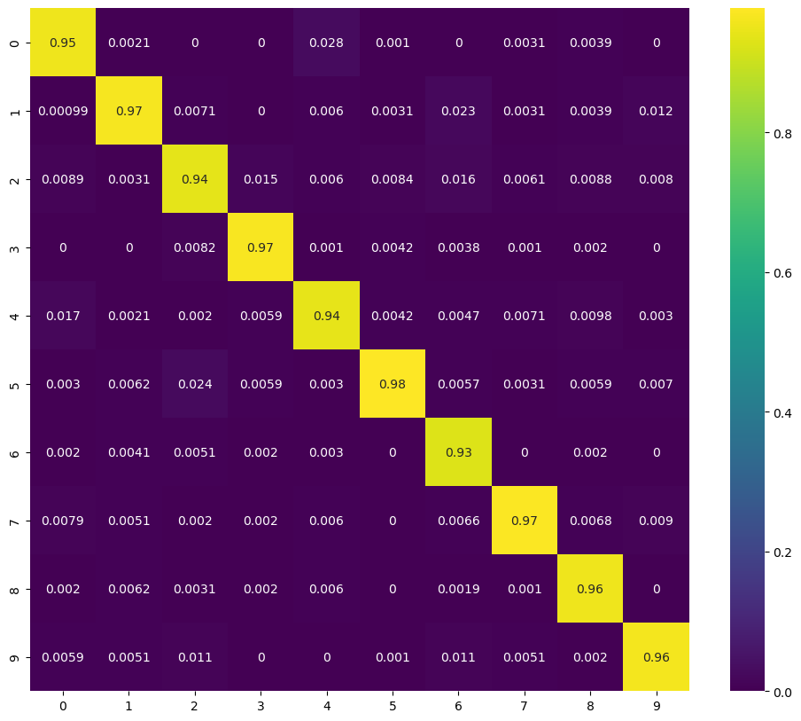

```python
plt.figure(figsize=(12, 10))
sns.heatmap(confusion_matrix(y_test, y_pred, normalize='pred'), cmap='viridis', annot=True)
plt.show()
```

# To display japanese characters

```python
!pip install japanize-matplotlib
```

```python
import japanize_matplotlib

kmnist_classmap = pd.read_csv('/kaggle/input/kuzushiji/kmnist_classmap.csv')
kmnist_classmap.head()
```

|  | index | codepoint | char |
| --- | --- | --- | --- |
| 0 | 0 | U+304A | お |
| 1 | 1 | U+304D | き |
| 2 | 2 | U+3059 | す |
| 3 | 3 | U+3064 | つ |
| 4 | 4 | U+306A | な |

```python
idx_error = []
for i in range(len(y_test)):
    if y_pred[i] != y_test[i]:
        idx_error.append(i)
```

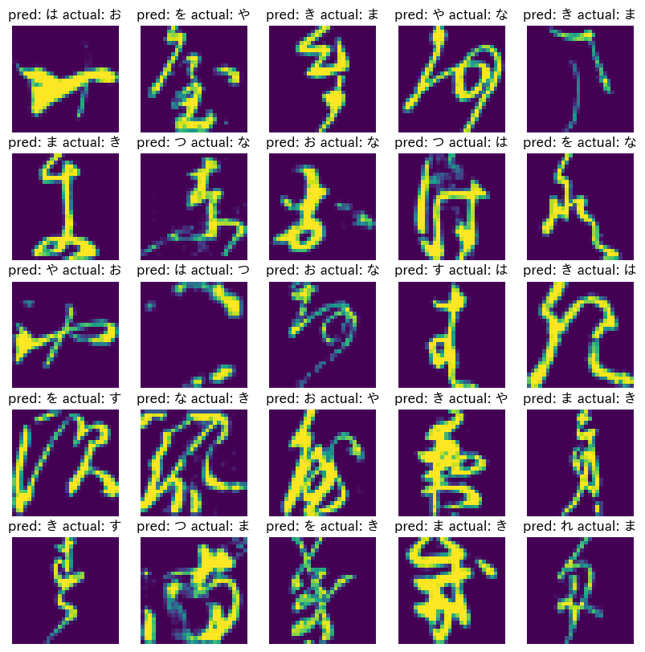

```python
plt.figure(figsize=(10, 10))
for i in range(25):
    idx = idx_error[i]
    pred = kmnist_classmap.loc[y_pred[idx], 'char']
    actual = kmnist_classmap.loc[y_test[idx], 'char']
    plt.subplot(5, 5, i + 1)
    plt.imshow(X_test[idx], cmap='viridis')
    plt.title(f'pred: {pred} actual: {actual}')
    plt.axis('off')
    plt.grid(False)
plt.show()
```

**You can see that the error in the predictions lies in hard cases, leading to confusion between similar characters. My CNN model is customized from the VGG16 architecture (you can call it by VGG4), which is a very popular architecture for image classification. Additionally, I have used Batch Normalization to speed up the training process and Dropout to prevent overfitting. Furthermore, I implemented a Learning Rate Scheduler to reduce the learning rate after a few epochs, which helps the model converge faster**

**Overall, the model is doing a good job and serves as a solid baseline for further improvements.**

**Thank you for reading my notebook. I hope you enjoy it.**